# HW 9

SDS322E

November 08, 2021

## Vaishnavi Sathiyamoorthy vs25229

**Please submit as a knitted HTML file on Canvas before the due date**

*For all questions, include the R commands/functions that you used to find your answer. Answers without supporting code will not receive credit.*

> **Review of how to submit this assignment** All homework assignments will be completed using R Markdown. These `.Rmd` files consist of text/syntax (formatted using Markdown) alongside embedded R code. When you have completed the assignment (by adding R code inside codeblocks and supporting text outside of the codeblocks), create your document as follows:
> - Click the arrow next to the “Knit” button (above)
> - Choose “Knit to HTML” and wait; fix any errors if applicable
> - Go to Files pane and put checkmark next to the correct HTML file
> - Click on the blue gear icon (“More”) and click Export
> - Download the file and then upload to Canvas

### Question 1.1 (3 pts)

##### Take a look at the `swiss` dataset. It contains measurements of 6 socioecnomic variables for 47 French-speaking Swiss provinces/cantons from 1888. Variables are all recorded on a 0-100 scale and include `Fertility`, `Agriculture` (% in an agricultural occupation), `Examination` (% earning highest honors on army exam), `Education` (% with education beyond primary school), `Catholic` (% Catholic), and `Infant.Mortality` (% of live births surviving less than 1 year).

##### First, create a correlation matrix and visualize it with a correlation heatmap using ggplot2. Include `scale_fill_gradient2()` and label your tiles with the actual correlations using `geom_text(aes(label=...))`. Discuss what you see. Specifically, which variables are strongly positively correlated? Which variables are strongly negatively correlated? Which variable seems to be the least correlated with things like education and agriculture?

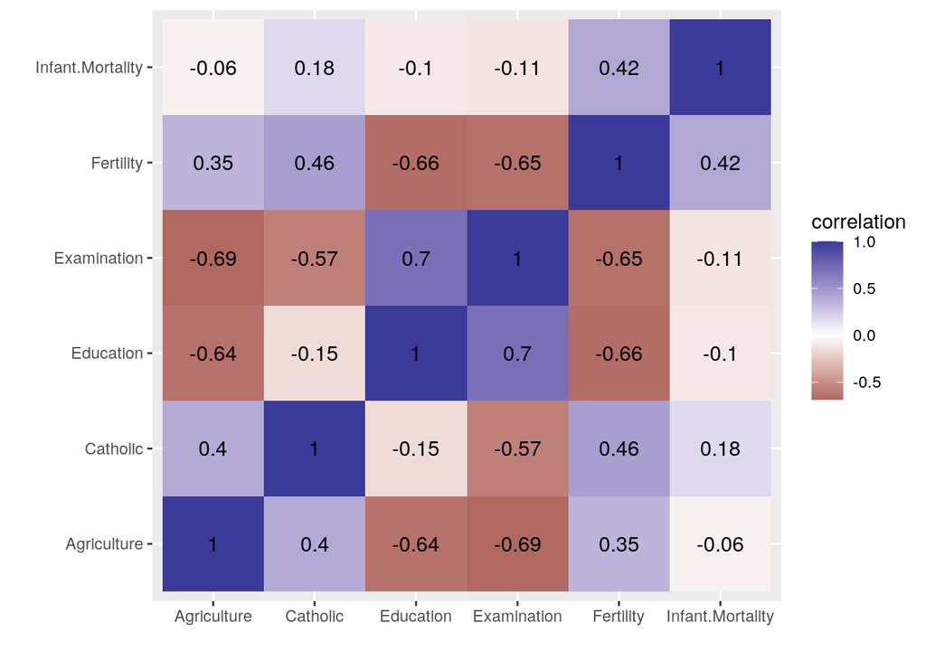

```r
library(tidyverse)
library(cluster)

swiss <- swiss
cor_mat <- swiss %>% cor(use = "pair") %>% as.data.frame() %>%
    rownames_to_column("var1") %>% pivot_longer(-1,
    names_to = "var2", values_to = "correlation")
cor_mat %>% ggplot(aes(var1, var2, fill = correlation)) +
    geom_tile() + scale_fill_gradient2() + geom_text(aes(label = round(correlation,
    2)), color = "black", size = 4) + xlab("") + ylab("")
```

### Question 1.2 (6 pts)

Now, using the `swiss` dataset (no need to standardize data first), perform a cluster analysis by (1) choosing the number of clusters that maximizes average silhouette width (try k=2 up to k=10), and (2) running the PAM clustering algorithm on the raw data for that many clusters (save the object as swiss_pam). Show all code for both steps.

Now, discuss the following: How good is the cluster solution in terms of overall average silhouette width? Which two provinces are the medoids (the representatives of their clusters)? What variables are they most similar on? Most different?

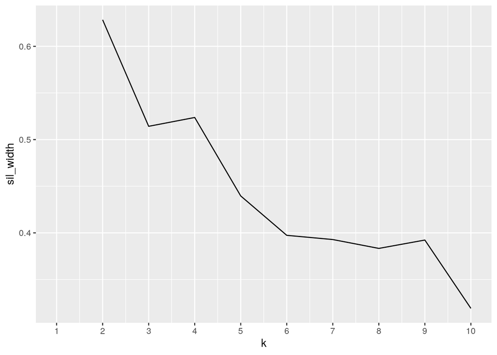

```r
library(cluster)
sil_width <- vector()
for (i in 2:10) {
    pam_fit <- pam(swiss, k = i)
    sil_width[i] <- pam_fit$silinfo$avg.width
}
ggplot() + geom_line(aes(x = 1:10, y = sil_width)) +
    scale_x_continuous(name = "k", breaks = 1:10)
```

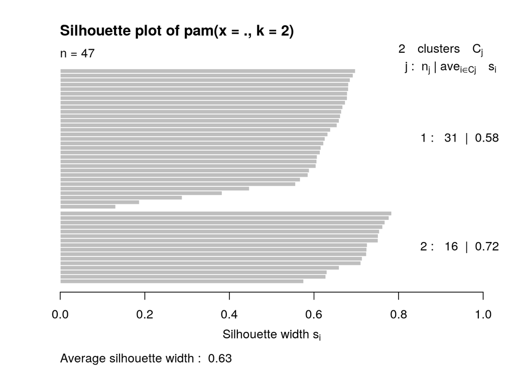

```r
swiss_pam <- swiss %>% pam(k = 2)
plot(swiss_pam, which = 2)
```

*The overall silhouette width is around 0.63. This width is reasonable. Yverdon and Monthey are the medoids. They are most similar in infant mortality and most different in catholic.*

### Question 1.3 (3 pts)

##### We used six variables here but can only really visualize data in up to three dimensions (and 2D is usually easier). To help us get a sense of the clusters, let’s take the `swiss` data, add the PAM cluster assignments as a factor or character variable (e.g., using mutate; call it `cluster`), and then plot every pairwise scatterplot using the `ggpairs(cols= 1:6, aes(color=cluster))` function. Give it a second to run (it is creating a lot of plots).

#### Which variable shows the greatest difference between the two clusters? Which variable shows the least difference between the two clusters? In terms of only `Fertility`, `Agriculture`, and `Examination`, use the information in the plots to describe/characterize the two clusters.

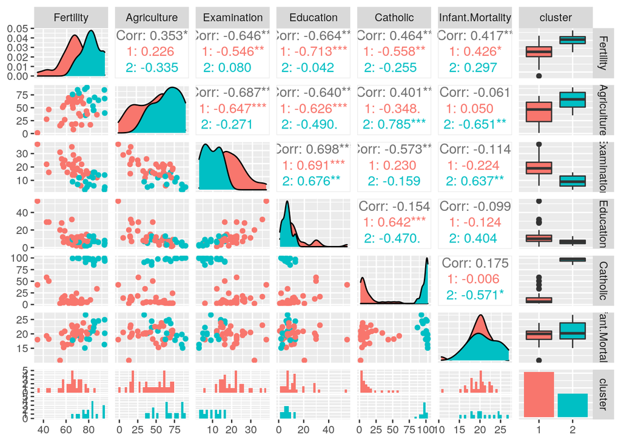

```r
library(GGally)
swiss %>% mutate(cluster = as.factor(swiss_pam$clustering)) %>%
    ggpairs(cols = 1:6, aes(color = cluster))
```

*Catholic shows the greatest difference between the 2 clusters and infant mortality shows the least difference between the two clusters. The fertility clusters have little within group variation and good between group variation. Agriculture has lots of within group variation and little between group variation. The examination clusters have little within group variation and good between group variation.*

### Question 2.1 (4 pts)

##### Read in the `ability` dataset. It contains six ability test scores for 112 individuals. The variable `general` is a non-verbal measure of general intelligence; `picture` is a picture-completion test; `blocks` is a block design task; `maze` is a maze-completion task; `reading` is a reading comprehension task; `vocabulary` is a vocabulary test.

##### Below, we take the dataset and perform principal component analysis on it. Keep PCs until you hit 85% of the total variance. Interpret each of those PCs by looking at the signs and magnitudes of the loadings: What do the PCs represent in terms of the original variables? What does it mean to score high/low on each of these components?

```r
ability <- read.csv("https://raw.githubusercontent.com/nathanielwoodward/ability/main/ability.csv")

pca1 <- princomp(ability, cor = T)
summary(pca1, loadings = T)
```

```
## Importance of components:
##                           Comp.1    Comp.2    Comp.3     Comp.4     Comp.5
## Standard deviation     1.7375788 1.1638432 0.8638203 0.60799551 0.55220906
## Proportion of Variance 0.5031967 0.2257552 0.1243642 0.06160976 0.05082247
## Cumulative Proportion  0.5031967 0.7289518 0.8533161 0.91492584 0.96574831
##                            Comp.6
## Standard deviation     0.45333223
## Proportion of Variance 0.03425169
## Cumulative Proportion  1.00000000
##
## Loadings:
##         Comp.1 Comp.2 Comp.3 Comp.4 Comp.5 Comp.6
## general  0.502                0.369  0.774
## picture  0.382  0.315  0.623 -0.599
## blocks   0.440  0.374         0.564 -0.579
## maze     0.294  0.442 -0.754 -0.341        -0.176
## reading  0.386 -0.568               -0.166 -0.706
## vocab    0.415 -0.492 -0.176 -0.266 -0.186  0.670
```

*The principle components determine how much variability in the data is accounted for by each variable. Larger PC values mean that there is greater variability in the data points, while smaller PC values mean that there is less variablitiy in the data points. PC1 shows that the higher the general score, the higher the the score is for other variables. PC2 shows that if there are high scores for picture, blocks, or maze, there tends to be a lower score for reading and vocab. PC3 shows that a higher score for picture tends to mean that maze and vocab were lower. PC4 shows that a higher score for general and blocks tends to lead to a lower score for picture, maze, and vocab. PC5 sgiws that a higher general score tends to have lower blocks, reading, and vocab scores. Finally, PC6 shows that a higher vocab score tends to have lower maze and reading scores.*

### Question 2.2 (1 pts)

##### The `scores` matrix inside of the `pca1` object contains the Principal Component scores for each of the 112 individuals for each of the 6 PCs. The first column (`Comp.1`) contains scores for all individuals on PC1, the second column (`Comp.2`) contains scores on PC2, etc. You can access it with `pca1$scores`.

##### To show that the 6 Principcal Components are uncorrelated with each other, compute the correlation matrix of all PC scores and pipe it into round(10).

```r
pca1$scores %>% cor %>% round(10)
```

```
##        Comp.1 Comp.2 Comp.3 Comp.4 Comp.5 Comp.6
## Comp.1      1      0      0      0      0      0
## Comp.2      0      1      0      0      0      0
## Comp.3      0      0      1      0      0      0
## Comp.4      0      0      0      1      0      0
## Comp.5      0      0      0      0      1      0
## Comp.6      0      0      0      0      0      1
```

### Question 2.3 (3 pts)

##### Take the matrix of PC scores, convert it to a dataframe, and add in the `general` column from the original `ability` dataset so it appears in this dataframe too (e.g., using mutate or bind_cols). Now, use this to create a plot of PC1 and PC2 scores for all 112 individuals using ggplot and color the points by the `general` variable. What do you notice? What is the correlation between scores on the `general` ability test and scores on `PC1`?

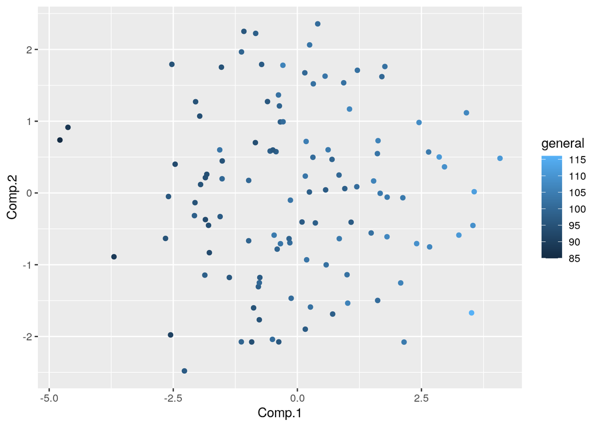

```r
pca1$scores %>% data.frame() %>% mutate(general = ability$general) %>%
    ggplot(aes(Comp.1, Comp.2, color = general)) +
    geom_point()
```

*Lower general scores on the abilities test tend to have lower comp 1 scores and higher general scores on the abilities test tend to have higher comp 1 values.*

```
## [1] "2021-11-08 18:36:06 CST"
```

[output not shown]